# WB Projekt nr 1

Bartłomiej Granat

12 - 06 - 2019

# 1 Wstęp

W celu wybrania optymalnego modelu dla zadanego zbioru wykonałem następujące kroki: – EDA – Znalezienie zbiorów danych o podobnym kształcie – Sprawdzenie, które modele zwracają najlepsze wyniki dla tych danych – Wybór najlepszego modelu i tuning jego parametrów

# 2 EDA

Zbiór przed obróbką

```r
introduce(test_new)
```

```
##   rows columns discrete_columns continuous_columns all_missing_columns
## 1 4184      22                0                 22                   0
##   total_missing_values complete_rows total_observations memory_usage
## 1                    0          4184              92048       372688
```

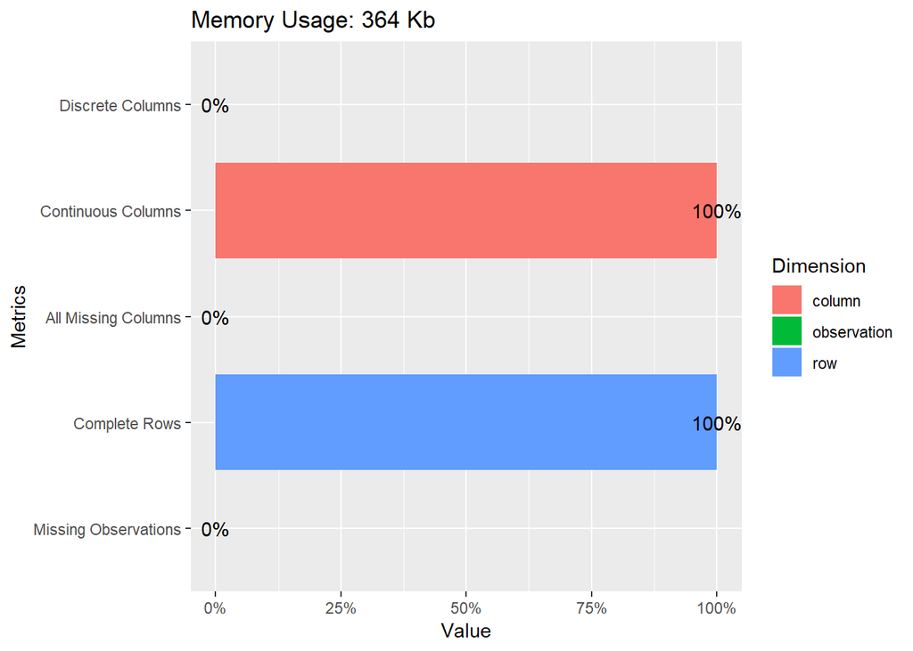

```r
plot_intro(test_new)
```

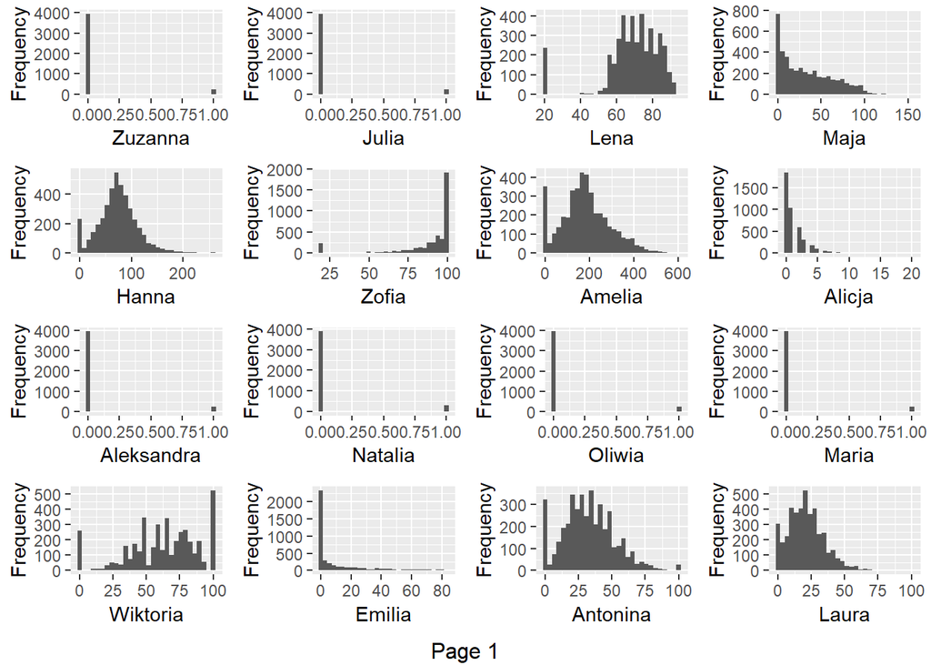

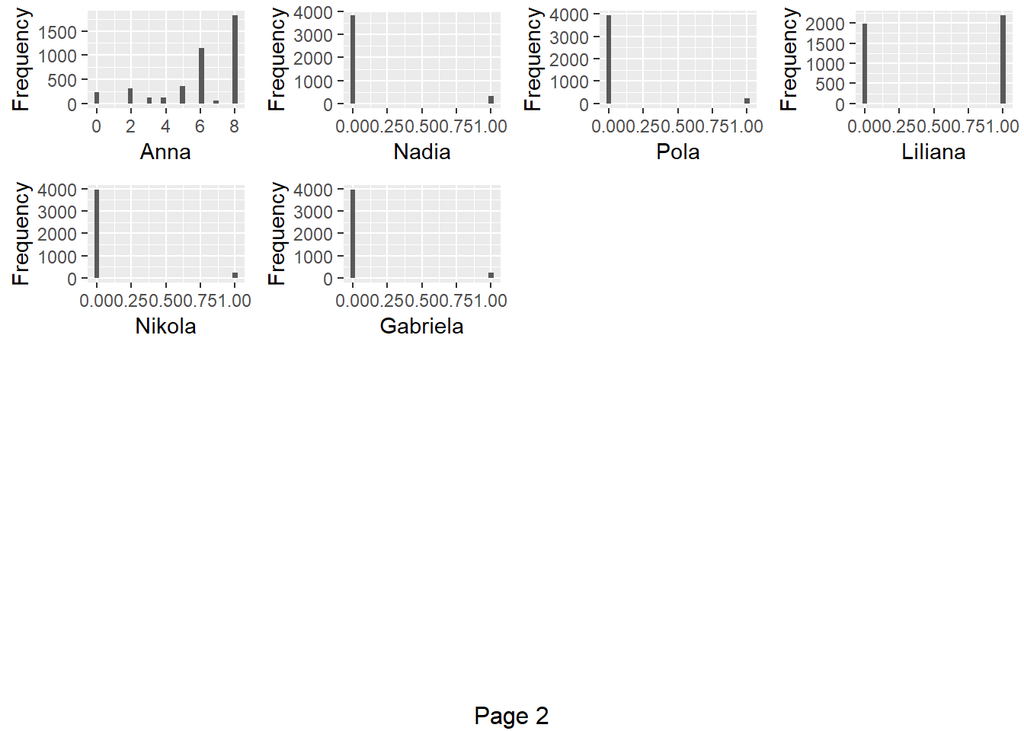

```r
plot_histogram(test_new)
```

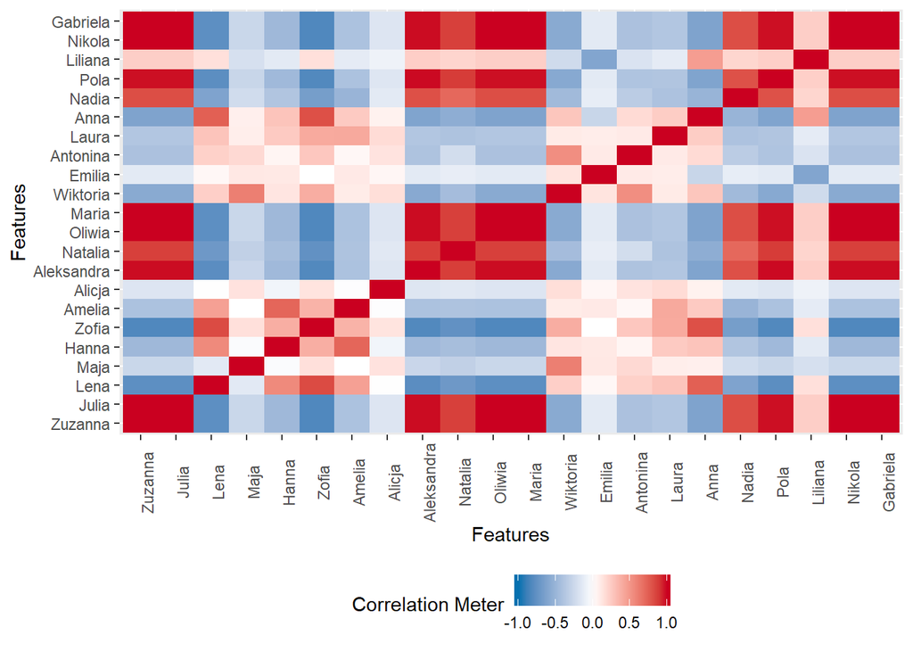

```r
plot_correlation(test_new)
```

Uporządkowany zbiór

```r
introduce(test)
```

```
##   rows columns discrete_columns continuous_columns all_missing_columns
## 1 4184      17                8                  9                   0
##   total_missing_values complete_rows total_observations memory_usage
## 1                    0          4184              71128       293256
```

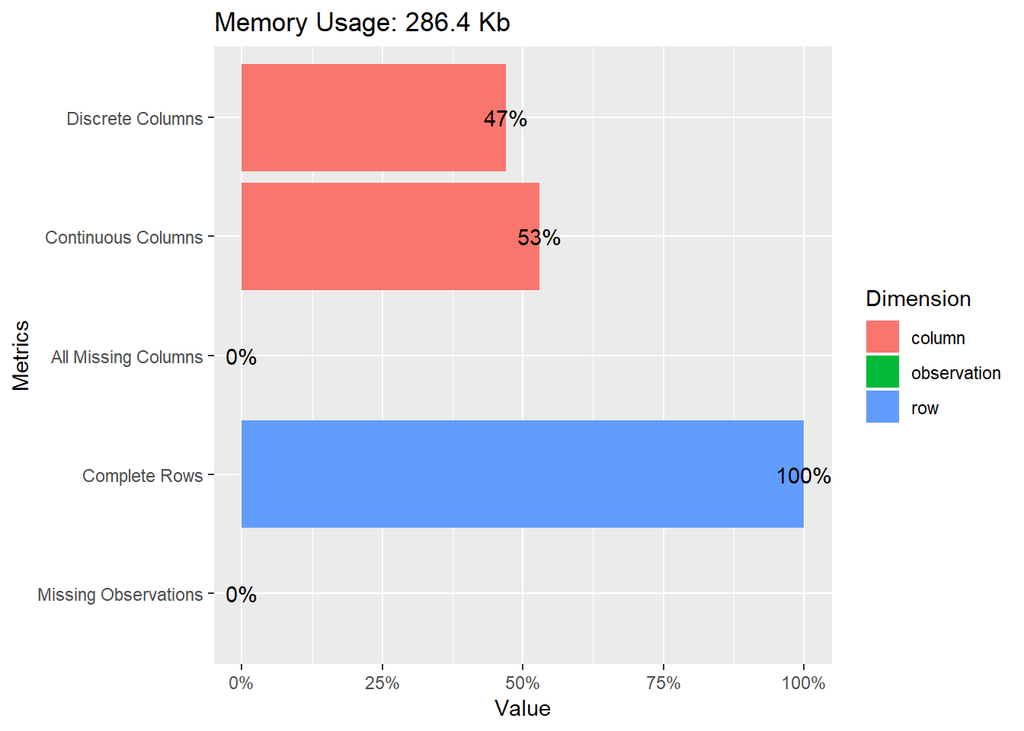

```r
plot_intro(test)
```

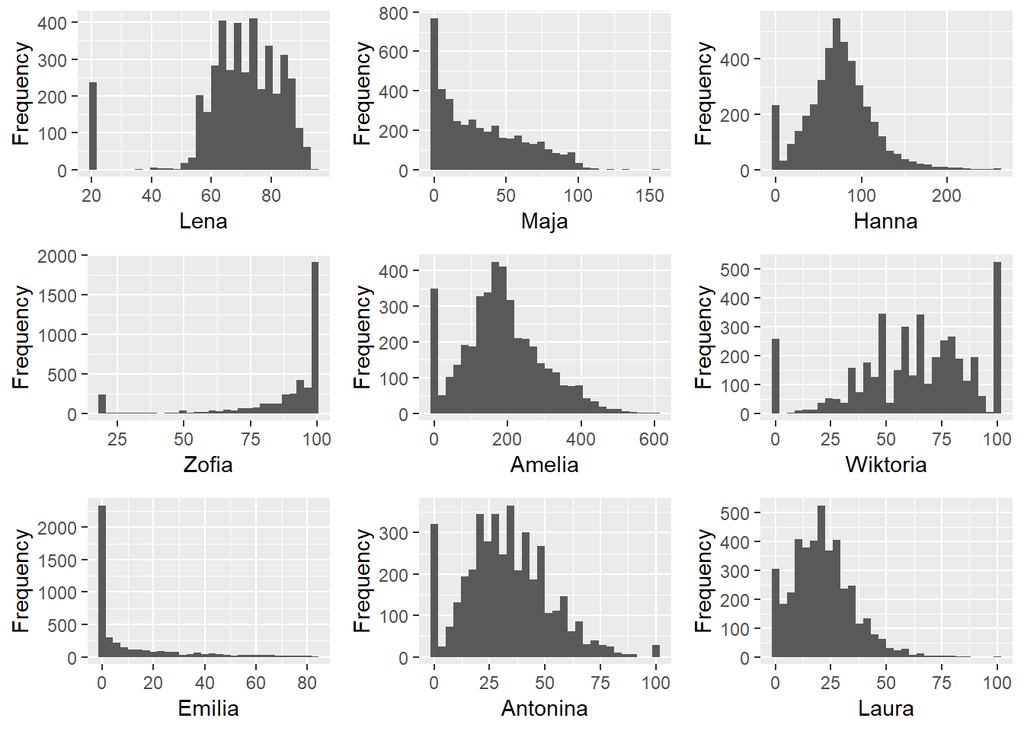

```r
plot_histogram(test)
```

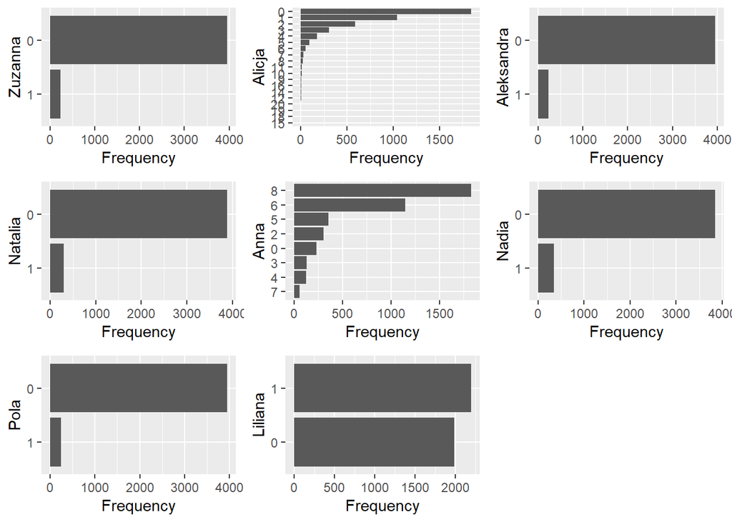

```r
plot_bar(test)
```

# 3 Podobne zbiory

```r
bank_marketing <- getOMLDataSet(data.id = 1558L)
bank_marketing_dat <- bank_marketing$data
classif_task1 <- makeClassifTask(id="bank_marketing", data = bank_marketing_dat, target = bank_marketing$target.features)

phoneme <- getOMLDataSet(data.id = 1489L)
phoneme_dat <- phoneme$data
classif_task2 <- makeClassifTask(id="phoneme", data = phoneme_dat, target = phoneme$target.features)

spambase <- getOMLDataSet(data.id = 44L)
spambase_dat <- spambase$data
classif_task3 <- makeClassifTask(id="spambase", data = spambase_dat, target = spambase$target.features)

thoracic_surgery <- getOMLDataSet(data.id = 4329L)
thoracic_surgery_dat <- thoracic_surgery$data
classif_task4 <- makeClassifTask(id="thoracic_surgery", data = thoracic_surgery_dat, target = thoracic_surgery$target.features)

BNG_vote <- getOMLDataSet(data.id = 143L)
BNG_vote_dat <- BNG_vote$data
classif_task5 <- makeClassifTask(id="BNG_vote", data = BNG_vote_dat, target = BNG_vote$target.features)
```

Zbiory, które wybrałem do znalezienia optymalnego modelu mają albo podobną liczbę zmiennych, albo obserwacji przy czym zbior bank_marketing_dat najbardziej przypomina nasz docelowy.

Zbiór testowy

```r
introduce(test)
```

```
##   rows columns discrete_columns continuous_columns all_missing_columns
## 1 4184      17                8                  9                   0
##   total_missing_values complete_rows total_observations memory_usage
## 1                    0          4184              71128       293256
```

Bank_marketing

```r
introduce(bank_marketing_dat)
```

```
##   rows columns discrete_columns continuous_columns all_missing_columns
## 1 4521      17               10                  7                   0
##   total_missing_values complete_rows total_observations memory_usage
## 1                    0          4521              76857       444048
```

Phoneme

```r
introduce(phoneme_dat)
```

```
##   rows columns discrete_columns continuous_columns all_missing_columns
## 1 5404       6                1                  5                   0
##   total_missing_values complete_rows total_observations memory_usage
## 1                    0          5404              32424       240120
```

Spambase

```r
introduce(spambase_dat)
```

```
##   rows columns discrete_columns continuous_columns all_missing_columns
## 1 4601      58                1                 57                   0
##   total_missing_values complete_rows total_observations memory_usage
## 1                    0          4601             266858      2128680
```

Thoracic_surgery

```r
introduce(thoracic_surgery_dat)
```

```
##   rows columns discrete_columns continuous_columns all_missing_columns
## 1  470      17               14                  3                   0
##   total_missing_values complete_rows total_observations memory_usage
## 1                    0           470               7990        48304
```

BNG_vote

```r
introduce(BNG_vote_dat)
```

```
##     rows columns discrete_columns continuous_columns all_missing_columns
## 1 131072      17               17                  0                   0
##   total_missing_values complete_rows total_observations memory_usage
## 1                    0        131072            2228224      8925256
```

# 4 Dopasowanie modeli

Poniżej znajdują się zagregowane wyniki dla wszystkich zbiorów i dla bank_marketing

```r
df <- as.data.frame(bmr)
aggregate(df[, 4:5], list(df$learner.id), mean)
```

```
##                    Group.1       acc       auc
## 1       classif.naiveBayes 0.7967406 0.8330622
## 2            classif.rpart 0.8761449 0.7910567
## 3       classif.adaboostm1 0.8728777 0.8280619
## 4          classif.h2o.glm 0.8783610 0.8576627
## 5 classif.h2o.randomForest 0.9133006 0.8929518
## 6          classif.h2o.gbm 0.9022638 0.8784807
```

```r
df2 <- df[df$task.id=="bank_marketing",]
aggregate(df2[, 4:5], list(df2$learner.id), mean)
```

```
##                    Group.1       acc       auc
## 1       classif.naiveBayes 0.8679494 0.8441312
## 2            classif.rpart 0.8986948 0.7416149
## 3       classif.adaboostm1 0.8896265 0.8430543
## 4          classif.h2o.glm 0.9026781 0.8916737
## 5 classif.h2o.randomForest 0.8971466 0.9070265
## 6          classif.h2o.gbm 0.8993585 0.9086145
```

Wybranym przeze mnie modelem jest zatem h2o.gbm

Przeprowadzę teraz tuning parametrów na zbiorze bank_marketing

```r
ind <- sample(dim(bank_marketing_dat)[1], round(0.7*dim(bank_marketing_dat)[1]))
data_train <- bank_marketing_dat[ind,]
data_test <- bank_marketing_dat[-ind,]

classif_task_pars <- makeClassifTask(id="radnomSearch", data = data_train, target = bank_marketing$target.features)

getParamSet(makeLearner("classif.h2o.gbm"))
```

```
##                           Type len   Def      Constr Req Tunable Trafo
## ntrees                 integer   -    50    1 to Inf   -    TRUE     -
## max_depth              integer   -     5    1 to Inf   -    TRUE     -
## min_rows               integer   -    10    1 to Inf   -    TRUE     -
## learn_rate             numeric   -   0.1      0 to 1   -    TRUE     -
## nbins                  integer   -    20    1 to Inf   -    TRUE     -
## nbins_cats             integer   -  1024    1 to Inf   -    TRUE     -
## balance_classes        logical   - FALSE           -   -    TRUE     -
## max_after_balance_size integer   -     1    0 to Inf   -    TRUE     -
## seed                   integer   -     - -Inf to Inf   -   FALSE     -
```

```r
ps = makeParamSet(
  makeNumericParam("learn_rate", lower = 0.005, upper = 0.01),
  makeDiscreteParam("ntrees", values = 200:500),
  makeDiscreteParam("max_depth", values = 7:20),
  makeDiscreteParam("min_rows", values = 2:15),
  makeDiscreteParam("nbins", values = 4:64)
)

ctrl = makeTuneControlRandom(maxit = 10L)

res = tuneParams("classif.h2o.gbm", task = classif_task_pars, resampling = cv,
                    par.set = ps, control = ctrl)

lrn = setHyperPars(makeLearner("classif.h2o.gbm", predict.type = "prob"), par.vals = res$x)
m = train(lrn, classif_task_pars)
p <- predict(m, newdata = data_test)
```

Domyślne parametry

```r
classif_task_fin <- makeClassifTask(id="bank_marketing", data = data_train, target = "Class")
learner <- makeLearner("classif.h2o.gbm", predict.type='prob')

m2 <- train(learner, classif_task_fin)
p2 <- predict(m2, newdata= data_test)
performance(p2,measures = list(acc,auc))
```

```
##       acc       auc
## 0.8974926 0.8898454
```

# 5 Faza 2

Tuning parametrów

```r
res$x
```

```
## $learn_rate
## [1] 0.008131176
##
## $ntrees
## [1] 496
##
## $max_depth
## [1] 14
##
## $min_rows
## [1] 10
##
## $nbins
## [1] 18
```

```r
performance(p,measures = list(acc,auc))
```

```
##       acc       auc
## 0.8886431 0.8896914
```

Ponieważ nie udało mi się poprawić modelu po uzyskaniu prawdziwych etykiet kilku obserwacji postanowiłem lepiej zapoznać się z tuningiem parametrów h2o.gbm. Na podstawie artykułu https://github.com/h2oai/h2o-3/blob/master/h2o-docs/src/product/tutorials/gbm/gbmTuning.Rmd oraz https://www.analyticsvidhya.com/blog/2016/02/complete-guide-parameter-tuning-gradient-boosting-gbm-python/ przeprowadziłem dodatkowy tuning przy użyciu biblioteki h2o.

## 5.1 Kluczowe parametry

1. ntrees - generalnie im większa liczba drzew tym większa dokładność
2. learn_rate - mniejsza wartość daje lepsze wyniki, jednak wymaga większej liczby drzew. Ten parametr kontroluje jak duży wpływ na wynik modelu ma każde kolejne drzewo
3. max_depth - maksymalna głębokość pojedynczego drzewa ogranicza zdolność modelu do przeuczenia
4. nbins - określa liczbę kontenerów koniecnzych do stworzenia histogramu, który jest następnie dzielony w optymalnym punkcjie
5. min_rows - minimalna liczba obserwacji zawartych w liściu

## 5.2 Zakres maxdepth

Parametr max_depth ma duży wpływ na trening modelu, a wartości optymalne są mocno powiązane ze zbiorem danych.

```r
df <- as.h2o(bank_marketing_dat)

response <- "Class"
predictors <- names(df)[-17]

splits <- h2o.splitFrame(
  data = df,
  ratios = c(0.8),   ## only need to specify 2 fractions, the 3rd is implied
  destination_frames = c("train.hex", "test.hex"), seed = 1234
)
train <- splits[[1]]
test  <- splits[[2]]

gbm <- h2o.gbm(x = predictors, y = response, training_frame = train, nfolds = 5, seed = 0xDECAF)
## Show a detailed summary of the cross validation metrics
## This gives you an idea of the variance between the folds
gbm@model$cross_validation_metrics_summary
```

```
## Cross-Validation Metrics Summary:
##                               mean           sd cv_1_valid cv_2_valid
## accuracy                  0.883718  0.012603958 0.86551267        0.9
## auc                      0.9071123  0.005745508  0.9073077 0.91748846
## err                     0.11628199  0.012603958 0.13448735        0.1
## err_count                     85.0    11.269427      101.0       70.0
## f0point5                 0.5245991  0.031941913 0.44426495  0.5816555
## f1                       0.5739888  0.021235349   0.521327 0.59770113
## f2                       0.6378923  0.026674453 0.63073397  0.6146572
## lift_top_group           5.2599096    0.7014649   6.258333  6.0240965
## logloss                 0.23121125  0.011047018 0.22551006 0.22071548
## max_per_class_error     0.30725032  0.047181778 0.26666668 0.37349397
## mcc                     0.52196765  0.018026378  0.4776604 0.54148906
## mean_per_class_accuracy  0.8000822  0.014072008  0.8067554 0.78164846
## mean_per_class_error    0.19991781  0.014072008 0.19324458 0.21835153
## mse                     0.07127367 0.0041254354 0.07097671 0.06706329
## precision               0.49725324  0.038980693 0.40441176  0.5714286
## r2                       0.2856034  0.033428337  0.2104352 0.35832125
## recall                   0.6927497  0.047181778 0.73333335 0.62650603
## rmse                    0.26675734 0.0075564445 0.26641455  0.2589658
## specificity             0.90741473  0.019725041  0.8801775 0.93679094
##                         cv_3_valid cv_4_valid  cv_5_valid
## accuracy                 0.8601307  0.9038997  0.88904697
## auc                     0.91359246 0.90277195   0.8944011
## err                     0.13986929 0.09610028 0.110953055
## err_count                    107.0       69.0        78.0
## f0point5                0.53205127  0.5450237        0.52
## f1                      0.60805863  0.5714286   0.5714286
## f2                       0.7094017  0.6005222  0.63414633
## lift_top_group            4.597356  3.6385136     5.78125
## logloss                 0.26085705 0.21712504  0.23184857
## max_per_class_error     0.20192307  0.3783784  0.31578946
## mcc                      0.5518341  0.5198586  0.51899624
## mean_per_class_accuracy  0.8339855  0.7789785  0.79904306
## mean_per_class_error    0.16601449 0.22102149  0.20095694
## mse                     0.08242145 0.06621334  0.06969357
## precision               0.49112427 0.52873564  0.49056605
## r2                       0.2983374 0.28372994  0.27719316
## recall                   0.7980769  0.6216216  0.68421054
## rmse                    0.28709137 0.25731954   0.2639954
## specificity              0.8698941  0.9363354   0.9138756
```

```r
## Get the cross-validated AUC by scoring the combined holdout predictions.
## (Instead of taking the average of the metrics across the folds)
h2o.auc(h2o.performance(gbm, xval = TRUE))
```

```
## [1] 0.9069658
```

Wynik dla domyślnych parametrów bez użycia mlr

```r
hyper_params = list( max_depth = seq(1,29,2) )

grid <- h2o.grid(
  ## hyper parameters
  hyper_params = hyper_params,

  ## full Cartesian hyper-parameter search
  search_criteria = list(strategy = "Cartesian"),

  ## which algorithm to run
  algorithm="gbm",

  ## identifier for the grid, to later retrieve it
  grid_id="depth_grid",

  ## standard model parameters
  x = predictors,
  y = response,
  training_frame = train,
  validation_frame = test,

  ## more trees is better if the learning rate is small enough
  ## here, use "more than enough" trees - we have early stopping
  ntrees = 10000,

  ## smaller learning rate is better
  ## since we have learning_rate_annealing, we can afford to start with a bigger learning rate
  learn_rate = 0.02,

  ## learning rate annealing: learning_rate shrinks by 1% after every tree
  ## (use 1.00 to disable, but then lower the learning_rate)
  learn_rate_annealing = 0.995,

  ## sample 80% of rows per tree
  sample_rate = 0.9,
  ## sample 80% of columns per split
  col_sample_rate = 0.9,

  ## fix a random number generator seed for reproducibility
  seed = 1234,

  ## early stopping once the validation AUC doesn't improve by at least 0.01% for 5 consecutive scoring events
  stopping_rounds = 5,
  stopping_tolerance = 1e-4,
  stopping_metric = "AUC",

  ## score every 10 trees to make early stopping reproducible (it depends on the scoring interval)
  score_tree_interval = 10
)
## by default, display the grid search results sorted by increasing logloss (since this is a classification task)

## sort the grid models by decreasing AUC
sortedGrid <- h2o.getGrid("depth_grid", sort_by="auc", decreasing = TRUE)

## find the range of max_depth for the top 5 models
topDepths = sortedGrid@summary_table$max_depth[1:5]
minDepth = min(as.numeric(topDepths))
maxDepth = max(as.numeric(topDepths))
minDepth
```

```
## [1] 11
```

```r
maxDepth
```

```
## [1] 19
```

Mając ten przedział przeprowadziłem tuning parametrów dla lepiej zdefiniowanych przedziałów. Nie uzyskałem jednak wyraźnej poprawy.

```r
hyper_params = list(
  ## restrict the search to the range of max_depth established above
  max_depth = seq(minDepth,maxDepth,1),

  ## search a large space of row sampling rates per tree
  sample_rate = seq(0.5,1,0.01),

  ## search a large space of column sampling rates per split
  col_sample_rate = seq(0.5,1,0.01),

  ## search a large space of column sampling rates per tree
  col_sample_rate_per_tree = seq(0.8,1,0.01),

  ## search a large space of how column sampling per split should change as a function of the depth of the split
  col_sample_rate_change_per_level = seq(0.8,1.1,0.01),

  ## search a large space of the number of min rows in a terminal node
  min_rows = 2^seq(0,log2(nrow(train))-1,1),

  ## search a large space of the number of bins for split-finding for continuous and integer columns
  nbins = 2^seq(4,10,1),

  ## search a large space of the number of bins for split-finding for categorical columns
  nbins_cats = 2^seq(4,12,1),

  ## search a few minimum required relative error improvement thresholds for a split to happen
  min_split_improvement = c(0,1e-8,1e-6),

  ## try all histogram types (QuantilesGlobal and RoundRobin are good for numeric columns with outliers)
  histogram_type = c("UniformAdaptive","QuantilesGlobal","RoundRobin")
)
search_criteria = list(
  ## Random grid search
  strategy = "RandomDiscrete",

  ## limit the runtime to 60 minutes
  max_runtime_secs = 600,

  ## build no more than 100 models
  max_models = 200,

  ## random number generator seed to make sampling of parameter combinations reproducible
  seed = 12,

  ## early stopping once the leaderboard of the top 5 models is converged to 0.1% relative difference
  stopping_rounds = 5,
  stopping_metric = "AUC",
  stopping_tolerance = 1e-5
)
grid <- h2o.grid(
  ## hyper parameters
  hyper_params = hyper_params,

  ## hyper-parameter search configuration (see above)
  search_criteria = search_criteria,

  ## which algorithm to run
  algorithm = "gbm",

  ## identifier for the grid, to later retrieve it
  grid_id = "final_grid",

  ## standard model parameters
  x = predictors,
  y = response,
  training_frame = train,
  validation_frame = test,

  ## more trees is better if the learning rate is small enough
  ## use "more than enough" trees - we have early stopping
  ntrees = 10000,

  ## smaller learning rate is better
  ## since we have learning_rate_annealing, we can afford to start with a bigger learning rate
  learn_rate = 0.01,

  ## learning rate annealing: learning_rate shrinks by 1% after every tree
  ## (use 1.00 to disable, but then lower the learning_rate)
  learn_rate_annealing = 1,

  ## early stopping based on timeout (no model should take more than 1 hour - modify as needed)
  max_runtime_secs = 600,

  ## early stopping once the validation AUC doesn't improve by at least 0.01% for 5 consecutive scoring events
  stopping_rounds = 5, stopping_tolerance = 1e-6, stopping_metric = "AUC",

  ## score every 10 trees to make early stopping reproducible (it depends on the scoring interval)
  score_tree_interval = 10,

  ## base random number generator seed for each model (automatically gets incremented internally for each model)
  seed = 12
)
## Sort the grid models by AUC
sortedGrid <- h2o.getGrid("final_grid", sort_by = "auc", decreasing = TRUE)


for (i in 1:5) {
  gbm <- h2o.getModel(sortedGrid@model_ids[[i]])
  print(h2o.auc(h2o.performance(gbm, valid = TRUE)))
}
```

```
## [1] 0.8992601
## [1] 0.8992601
## [1] 0.8973838
## [1] 0.8973838
## [1] 0.8969044
```

Ostatecznie na podstawie artykułów i licznych wyników tuningu parametrów zdecydowałem się na parametry: ‘learn_rate’ = 0.01, ‘ntrees’ = 500, ‘max_depth’ = 13, ‘nbins’ = 16, ‘min_rows’ = 6

Wynik dla bank_marketing jest lepszy od tego dla domyślnych parametrów, jednak trzeba pamiętać, że jest to inny zbiór niż ten, na którym przeprowadzimy klasyfikację i może to nie być najlepsza kombinacja

```r
set.seed(123)
classif_task_fin <- makeClassifTask(id="bank_marketing", data = data_train, target = "Class")
learner3 <- makeLearner("classif.h2o.gbm", predict.type='prob', par.vals = list('learn_rate' = 0.01, 'ntrees' = 500, 'max_depth' = 13, 'nbins' = 16, 'min_rows' = 6))

m3 <- train(learner3, classif_task_fin)
p3 <- predict(m3, newdata= data_test)

DT::datatable(rbind(c("acc",       "auc"),
c(0.9026549, 0.9204645)))
```

| V1 | V2 |
| --- | --- |
| acc | auc |
| 0.9026549 | 0.9204645 |

Porównanie moich parametrów i domyślnych dla zbiorów podobnych przy użyciu benchmark

```r
cv <- makeResampleDesc("CV", iters = 5)
tasks = list(classif_task1, classif_task2, classif_task3, classif_task4)
meas = list(acc,auc)
lrns = list( makeLearner("classif.h2o.gbm", predict.type = "prob", par.vals = list('learn_rate' = 0.01, 'ntrees' = 500, 'max_depth' = 13, 'nbins' = 16, 'min_rows' = 6)))
bmr = benchmark(lrns, tasks, cv, measures = meas)
df <- as.data.frame(bmr)
df <- aggregate(df[, 4:5], list(df$task.id), mean)


lrns = list( makeLearner("classif.h2o.gbm", predict.type = "prob"))
bmr2 = benchmark(lrns, tasks, cv, measures = meas)
df2 <- as.data.frame(bmr2)
df2 <- aggregate(df2[, 4:5], list(df2$task.id), mean)


df_fin <- cbind(df2$auc,df$auc)
rownames(df_fin) <- c("bank_marketing","phoneme","spambase","thoracic_surgery")
colnames(df_fin) <- c("auc_def", "auc_post")
DT::datatable(df_fin)
```

|  | auc_def | auc_post |
| --- | --- | --- |
| bank_marketing | 0.908025798299733 | 0.906563666542926 |
| phoneme | 0.93897346069607 | 0.959044583774569 |
| spambase | 0.984930948150626 | 0.987550280719516 |
| thoracic_surgery | 0.643965896972226 | 0.665151498434631 |